# Análisis factorial de las baterías O1–O4

Fecha de publicación

13 de noviembre de 2026

Este documento analiza la estructura factorial de las baterías O1–O4 de la Encuesta Sociedad de Consumo 2023. Usa la base `db_proc`, generada en `prep_colapso_10.qmd`, donde las categorías extremas con menos de 10% ya están colapsadas y O4 está invertida (valor alto = más acuerdo).

El flujo es:

- **Secciones 1 a 4.** Pruebas previas de pertinencia del análisis factorial, en la muestra completa.
- **Sección 5.** División aleatoria de la muestra en dos mitades.
- **Secciones 6 y 7.** Análisis factorial exploratorio (AFE) en la mitad 1: número de factores y depuración de ítems.
- **Sección 8.** Análisis factorial confirmatorio (AFC) en la mitad 2: comparación de modelos alternativos.
- **Sección 9.** Modelos de medida reducidos: subconjuntos de ítems con criterios más exigentes, que logran buen ajuste y confiabilidad.

Las pruebas previas son tres:

1. **Determinante de la matriz de correlaciones.** Si es muy cercano a cero (menor a 0,00001), hay multicolinealidad extrema.
2. **Prueba de esfericidad de Bartlett.** Contrasta la hipótesis de que la matriz de correlaciones es una matriz identidad, es decir, que los ítems no se correlacionan. Rechazarla (p < 0,05) es condición necesaria para factorizar.
3. **Medida de adecuación muestral de Kaiser-Meyer-Olkin (KMO).** Compara las correlaciones con las correlaciones parciales. Se calcula para el conjunto (KMO global) y para cada ítem (MSA).

Como los ítems son ordinales con 3 a 5 categorías, todas las pruebas usan la **matriz de correlaciones policóricas**. Al final se compara con la matriz de Pearson como análisis de sensibilidad.

**Código**

```r
library(tidyverse)
library(haven)
library(here)
library(psych)
library(GPArotation)
library(lavaan)
library(knitr)
library(kableExtra)
options(knitr.kable.NA = "")

db_proc <- readRDS(here("input", "data", "proc", "db_proc.rds"))

items <- db_proc %>%
  select(matches("^O[1-4]_\\d+$")) %>%
  mutate(across(everything(), ~ as.numeric(zap_labels(.x))))

etiquetas <- map_chr(db_proc %>% select(all_of(names(items))),
                     ~ str_remove(attr(.x, "label"), "_[^_]*$"))

n <- nrow(items)

# Conjuntos de ítems a evaluar
conjuntos <- list(
  "O1–O4 (46 ítems)"     = names(items),
  "Prácticas O1–O3"      = grep("^O[1-3]_", names(items), value = TRUE),
  "O1 Prácticas de consumo"           = grep("^O1_", names(items), value = TRUE),
  "O2 Prácticas cotidianas"           = grep("^O2_", names(items), value = TRUE),
  "O3 Consumo crítico y político"     = grep("^O3_", names(items), value = TRUE),
  "O4 Actitudes hacia el reciclaje"   = grep("^O4_", names(items), value = TRUE)
)
```

La base tiene 1623 casos y 46 ítems. La razón casos por ítem es 35.3, por sobre el mínimo habitual de 10.

# 1. Matriz de correlaciones policóricas

**Código**

```r
poly <- polychoric(items)
R_poly <- poly$rho

# Verificar que la matriz sea definida positiva
autovalores <- eigen(R_poly, only.values = TRUE)$values
definida_positiva <- all(autovalores > 0)

if (!definida_positiva) {
  R_poly <- cor.smooth(R_poly)
}
```

La matriz policórica es definida positiva. Su autovalor mínimo es 0.2505.

**Código**

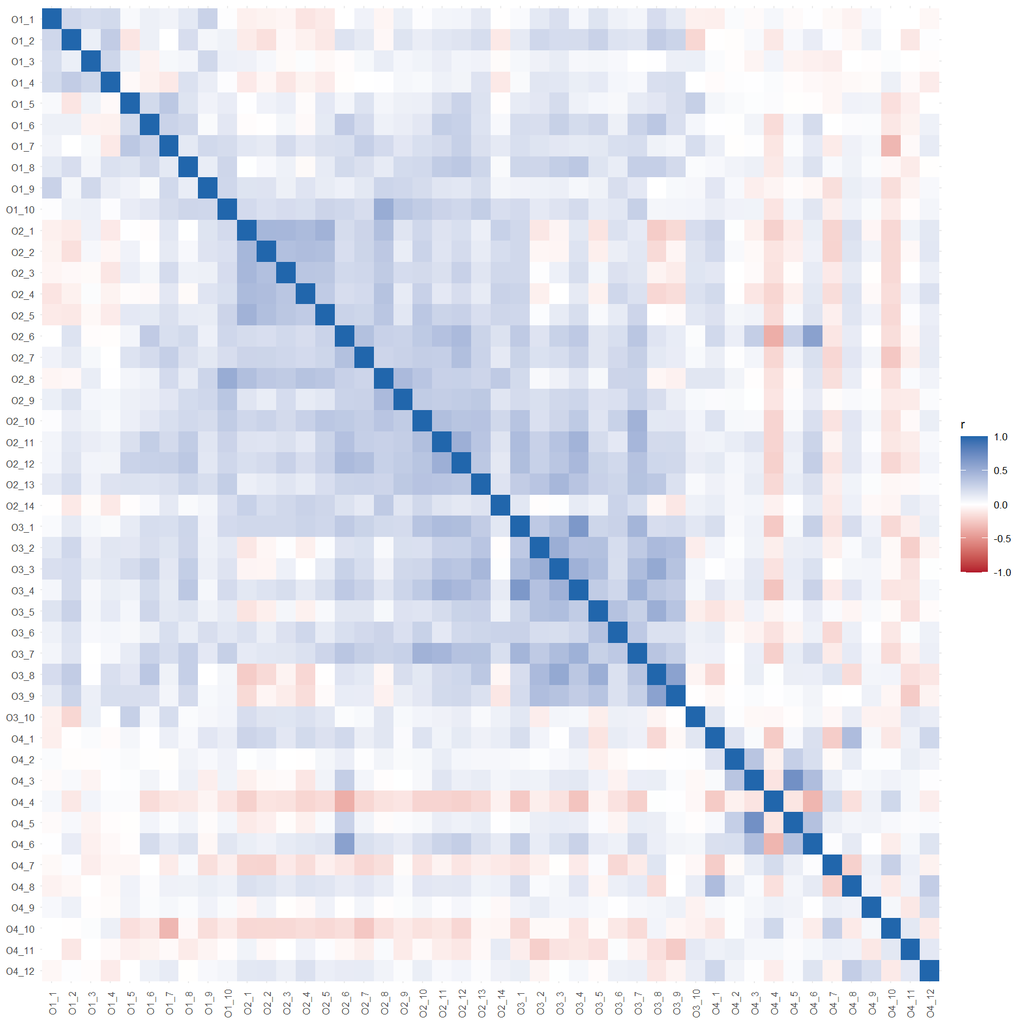

Figura 1: Correlaciones policóricas entre los 46 ítems

```r
R_poly %>%
  as.data.frame() %>%
  rownames_to_column("item1") %>%
  pivot_longer(-item1, names_to = "item2", values_to = "r") %>%
  mutate(across(c(item1, item2), ~ factor(.x, levels = names(items)))) %>%
  ggplot(aes(item1, fct_rev(item2), fill = r)) +
  geom_tile() +
  scale_fill_gradient2(low = "#b2182b", mid = "white", high = "#2166ac",
                       midpoint = 0, limits = c(-1, 1)) +
  labs(x = NULL, y = NULL, fill = "r") +
  theme_minimal(base_size = 8) +
  theme(axis.text.x = element_text(angle = 90, vjust = 0.5))
```

## Ítems con correlaciones débiles

Un ítem que no se correlaciona al menos 0,30 con ningún otro difícilmente cargará en un factor común.

**Código**

```r
R_sin_diag <- R_poly
diag(R_sin_diag) <- NA

max_r <- tibble(
  item = names(items),
  enunciado = etiquetas,
  r_max = apply(abs(R_sin_diag), 1, max, na.rm = TRUE),
  n_r_030 = apply(abs(R_sin_diag) >= 0.30, 1, sum, na.rm = TRUE)
) %>%
  arrange(r_max)

max_r %>%
  filter(r_max < 0.30) %>%
  kable(digits = 2,
        col.names = c("Ítem", "Enunciado", "Correlación máxima (abs.)", "N° de correlaciones ≥ 0,30 (abs.)"),
        caption = "Ítems sin ninguna correlación de 0,30 o más") %>%
  kable_styling(full_width = FALSE)
```

Ítems sin ninguna correlación de 0,30 o más

| Ítem | Enunciado | Correlación máxima (abs.) | N° de correlaciones ≥ 0,30 (abs.) |
| --- | --- | --- | --- |
| O4_9 | Consumir menos es mejor que reciclar | 0.21 | 0 |
| O4_11 | Lo que compramos o dejamos de comprar es un problema de cada persona | 0.24 | 0 |
| O1_3 | Ve alguna serie o película en Netflix, Youtube o similar | 0.25 | 0 |
| O1_1 | Compra algún producto en Amazon, Ali Express, E-Bay, Wish u otra tienda fuera del país | 0.28 | 0 |
| O1_9 | Compara precios en internet antes de comprar | 0.28 | 0 |
| O4_7 | Me cuesta creer que un envase reciclado sirva de algo para el medioambiente | 0.29 | 0 |
| O3_10 | Compra en pequeños negocios | 0.29 | 0 |

# 2. Determinante, Bartlett y KMO por conjunto de ítems

**Código**

```r
pruebas_previas <- function(vars, R_total, n) {
  R <- R_total[vars, vars]
  bart <- cortest.bartlett(R, n = n)
  kmo  <- KMO(R)
  tibble(
    n_items      = length(vars),
    determinante = det(R),
    bartlett_chi2 = bart$chisq,
    bartlett_gl   = bart$df,
    bartlett_p    = bart$p.value,
    kmo_global    = kmo$MSA,
    msa_min       = min(kmo$MSAi),
    item_msa_min  = names(which.min(kmo$MSAi))
  )
}

tabla_pruebas <- imap_dfr(conjuntos, ~ pruebas_previas(.x, R_poly, n) %>%
                            mutate(conjunto = .y, .before = 1))

tabla_pruebas %>%
  mutate(
    determinante  = formatC(determinante, format = "e", digits = 2),
    bartlett_chi2 = formatC(bartlett_chi2, format = "f", digits = 1, big.mark = "."),
    bartlett_p    = if_else(bartlett_p < 0.001, "< 0,001", formatC(bartlett_p, digits = 3))
  ) %>%
  kable(digits = 3,
        col.names = c("Conjunto", "Ítems", "Determinante", "Bartlett χ²", "gl", "p",
                      "KMO global", "MSA mínimo", "Ítem con MSA mínimo"),
        caption = "Pruebas de pertinencia del análisis factorial (correlaciones policóricas)") %>%
  kable_styling(bootstrap_options = c("striped", "condensed"))
```

Pruebas de pertinencia del análisis factorial (correlaciones policóricas)

| Conjunto | Ítems | Determinante | Bartlett χ² | gl | p | KMO global | MSA mínimo | Ítem con MSA mínimo |
| --- | --- | --- | --- | --- | --- | --- | --- | --- |
| O1–O4 (46 ítems) | 46 | 4.54e-07 | 23.454.2 | 1035 | < 0,001 | 0.874 | 0.542 | O4_9 |
| Prácticas O1–O3 | 34 | 1.85e-05 | 17.546.6 | 561 | < 0,001 | 0.893 | 0.681 | O1_3 |
| O1 Prácticas de consumo | 10 | 3.46e-01 | 1.717.6 | 45 | < 0,001 | 0.646 | 0.609 | O1_5 |
| O2 Prácticas cotidianas | 14 | 2.70e-02 | 5.840.3 | 91 | < 0,001 | 0.892 | 0.837 | O2_9 |
| O3 Consumo crítico y político | 10 | 4.36e-02 | 5.066.9 | 45 | < 0,001 | 0.827 | 0.447 | O3_10 |
| O4 Actitudes hacia el reciclaje | 12 | 1.32e-01 | 3.277.2 | 66 | < 0,001 | 0.676 | 0.469 | O4_9 |

Criterios de interpretación del KMO (Kaiser, 1974):

Escala de Kaiser para el KMO

| KMO | Interpretación |
| --- | --- |
| ≥ 0,90 | Excelente |
| 0,80–0,89 | Muy bueno |
| 0,70–0,79 | Aceptable |
| 0,60–0,69 | Mediocre |
| 0,50–0,59 | Bajo |
| < 0,50 | Inaceptable |

El determinante de la matriz de 46 ítems es por construcción muy pequeño: con muchos ítems, el determinante tiende a cero aunque no haya multicolinealidad. Es más informativo mirarlo por batería.

# 3. Adecuación muestral por ítem (MSA)

El MSA de cada ítem se calcula dentro del conjunto completo de 46 ítems y dentro de su propia batería. Un MSA menor a 0,50 es inaceptable; entre 0,50 y 0,60, dudoso. Aquí solo se identifican: la decisión de excluir ítems se toma junto con el análisis factorial exploratorio.

**Código**

```r
msa_total <- KMO(R_poly)$MSAi

msa_bateria <- map(conjuntos[3:6], ~ KMO(R_poly[.x, .x])$MSAi) %>%
  unname() %>%
  unlist()

tabla_msa <- tibble(
  item = names(items),
  enunciado = etiquetas,
  msa_total = msa_total[names(items)],
  msa_bateria = msa_bateria[names(items)]
) %>%
  mutate(
    clasificacion = cut(msa_total,
                        breaks = c(-Inf, 0.5, 0.6, 0.7, 0.8, 0.9, Inf),
                        labels = c("Inaceptable", "Bajo", "Mediocre",
                                   "Aceptable", "Muy bueno", "Excelente"),
                        right = FALSE)
  )

tabla_msa %>%
  arrange(msa_total) %>%
  kable(digits = 2,
        col.names = c("Ítem", "Enunciado", "MSA (46 ítems)", "MSA (batería)", "Clasificación"),
        caption = "Adecuación muestral por ítem, de menor a mayor") %>%
  kable_styling(bootstrap_options = c("striped", "condensed")) %>%
  row_spec(which(arrange(tabla_msa, msa_total)$msa_total < 0.6), bold = TRUE)
```

Adecuación muestral por ítem, de menor a mayor

| Ítem | Enunciado | MSA (46 ítems) | MSA (batería) | Clasificación |
| --- | --- | --- | --- | --- |
| O4_9 | Consumir menos es mejor que reciclar | 0.54 | 0.47 | Bajo |
| O1_3 | Ve alguna serie o película en Netflix, Youtube o similar | 0.68 | 0.67 | Mediocre |
| O4_5 | En mi comuna o barrio es fácil reciclar | 0.69 | 0.65 | Mediocre |
| O4_3 | Es fácil llevar mi reciclaje hasta los centros de acopio | 0.69 | 0.64 | Mediocre |
| O3_10 | Compra en pequeños negocios | 0.73 | 0.45 | Aceptable |
| O1_1 | Compra algún producto en Amazon, Ali Express, E-Bay, Wish u otra tienda fuera del país | 0.73 | 0.67 | Aceptable |
| O4_11 | Lo que compramos o dejamos de comprar es un problema de cada persona | 0.74 | 0.50 | Aceptable |
| O4_12 | Me considero más un ciudadano que un consumidor | 0.75 | 0.65 | Aceptable |
| O1_4 | Usa Uber, Rappi o Pedidos Ya | 0.75 | 0.63 | Aceptable |
| O1_5 | Compra ropa de segunda mano | 0.76 | 0.61 | Aceptable |
| O4_2 | Es fácil entender el etiquetado de los envases para separar el reciclaje | 0.77 | 0.81 | Aceptable |
| O4_7 | Me cuesta creer que un envase reciclado sirva de algo para el medioambiente | 0.79 | 0.68 | Aceptable |
| O1_9 | Compara precios en internet antes de comprar | 0.79 | 0.63 | Aceptable |
| O4_8 | Reciclar es bueno para la economía | 0.81 | 0.70 | Muy bueno |
| O4_10 | Con la vida apurada de hoy, es mejor comprar algo nuevo que reparar algo que no funciona | 0.81 | 0.66 | Muy bueno |
| O1_2 | Viaja fuera del país en avión | 0.83 | 0.61 | Muy bueno |
| O4_1 | Es necesario hacerse cargo de las tareas de reciclaje | 0.83 | 0.71 | Muy bueno |
| O3_9 | Participa en marchas o movilizaciones | 0.84 | 0.83 | Muy bueno |
| O3_8 | Participa en asociaciones de consumidores, cooperativas o grupos organizados de compradores | 0.84 | 0.78 | Muy bueno |
| O3_6 | Realiza un reclamo en el lugar de venta cuando un producto o servicio no lo satisface | 0.85 | 0.78 | Muy bueno |
| O4_6 | En mi hogar, todos/as reciclamos | 0.85 | 0.77 | Muy bueno |
| O1_7 | Repara su ropa, accesorios y/o electrodomésticos | 0.86 | 0.65 | Muy bueno |
| O3_5 | Realiza un reclamo o demanda colectiva en el Sernac | 0.87 | 0.84 | Muy bueno |
| O1_6 | Cultiva y cosecha sus propios alimentos | 0.88 | 0.66 | Muy bueno |
| O2_8 | Planifica compra de alimentos. | 0.88 | 0.89 | Muy bueno |
| O2_14 | Pide la boleta de los productos que compra | 0.88 | 0.92 | Muy bueno |
| O1_10 | Elabora un presupuesto mensual para monitorear mis gastos | 0.88 | 0.66 | Muy bueno |
| O2_2 | Corta el agua mientras se lava los dientes. | 0.89 | 0.90 | Muy bueno |
| O2_1 | Evita dejar luces prendidas en ambiente desocupados | 0.89 | 0.86 | Muy bueno |
| O2_6 | Separa la basura de su hogar para reciclaje. | 0.89 | 0.92 | Muy bueno |
| O4_4 | No tengo tiempo para hacerme cargo de todo lo que implica reciclar | 0.89 | 0.70 | Muy bueno |
| O2_9 | Planifica compras de vestuario. | 0.90 | 0.84 | Muy bueno |
| O2_5 | Desenchufa aparatos eléctricos cuando no los está ocupando. | 0.90 | 0.90 | Excelente |
| O2_4 | Espera que los alimentos se enfríen antes de guardarlos en el refrigerador. | 0.91 | 0.90 | Excelente |
| O3_4 | Compra un producto exclusivamente porque no daña el medioambiente en desmedro de otro, aunque sea más caro. | 0.91 | 0.82 | Excelente |
| O3_1 | Deja de comprar un producto porque se ha enterado de que daña el medioambiente, aunque sea más barato. | 0.91 | 0.77 | Excelente |
| O2_3 | Toma duchas cortas | 0.91 | 0.91 | Excelente |
| O3_2 | Intenta influir en lo que consumen otras personas | 0.91 | 0.89 | Excelente |
| O3_3 | Uso mis redes sociales para promover productos o empresas que considero éticas o sostenibles | 0.92 | 0.87 | Excelente |
| O1_8 | Adquiere productos con la etiqueta “comercio justo” | 0.92 | 0.69 | Excelente |
| O2_13 | Comenta información sobre los productos y empresas. | 0.93 | 0.90 | Excelente |
| O2_11 | Compra productos orgánicos o naturales. | 0.94 | 0.88 | Excelente |
| O2_7 | Re-utiliza papel en la impresión de documentos. | 0.94 | 0.91 | Excelente |
| O3_7 | Se informa respecto de dónde viene la ropa, alimentos y otros productos que consume | 0.94 | 0.90 | Excelente |
| O2_10 | Lee la etiqueta de los productos antes de decidir compra. | 0.95 | 0.92 | Excelente |
| O2_12 | Compra productos hechos con material reciclado. | 0.96 | 0.88 | Excelente |

**Código**

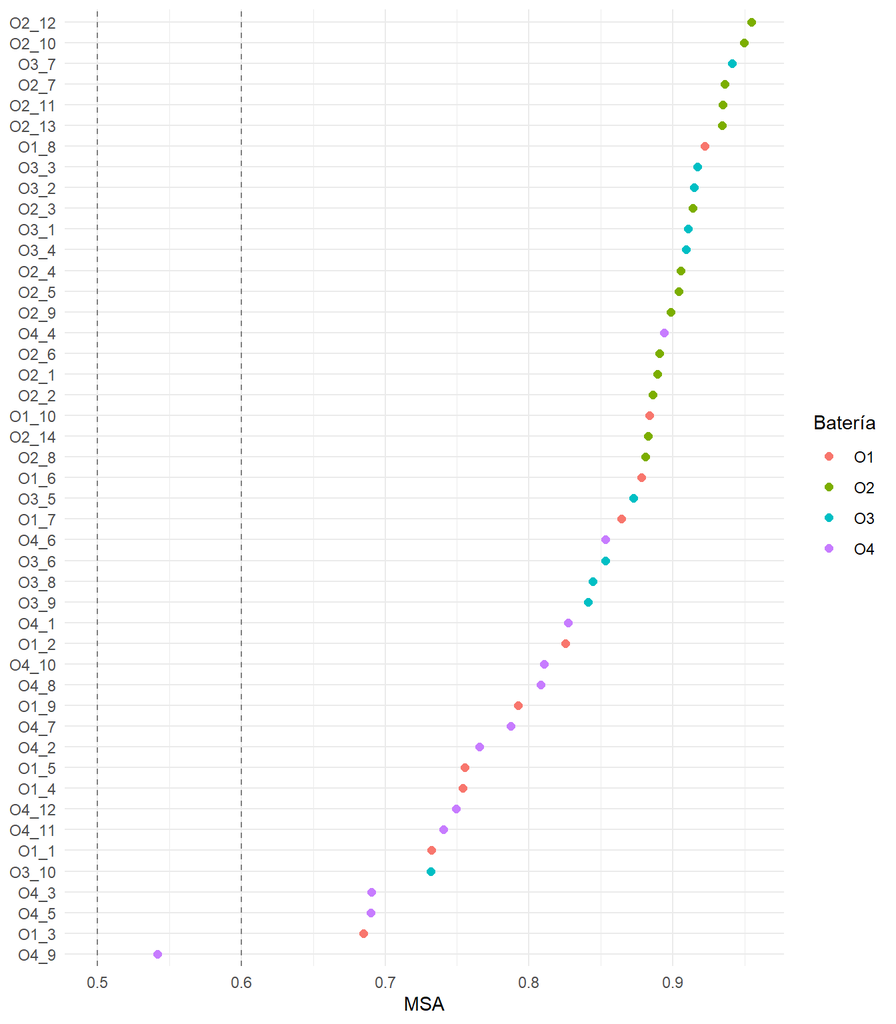

Figura 2: MSA por ítem en el conjunto de 46 ítems. Líneas en 0,50 y 0,60.

```r
tabla_msa %>%
  mutate(bateria = str_extract(item, "^O\\d"),
         item = fct_reorder(item, msa_total)) %>%
  ggplot(aes(msa_total, item, colour = bateria)) +
  geom_vline(xintercept = c(0.5, 0.6), linetype = "dashed", colour = "grey50") +
  geom_point(size = 2) +
  labs(x = "MSA", y = NULL, colour = "Batería") +
  theme_minimal()
```

# 4. Sensibilidad: correlaciones de Pearson

Muchos trabajos reportan Bartlett y KMO sobre la matriz de Pearson. Se presenta la comparación para mostrar que la conclusión no depende del tipo de correlación.

**Código**

```r
R_pear <- cor(items)

tabla_pear <- imap_dfr(conjuntos, ~ pruebas_previas(.x, R_pear, n) %>%
                         mutate(conjunto = .y, .before = 1))

tibble(
  Conjunto = tabla_pruebas$conjunto,
  `KMO policórica` = tabla_pruebas$kmo_global,
  `KMO Pearson` = tabla_pear$kmo_global,
  `Bartlett χ² policórica` = tabla_pruebas$bartlett_chi2,
  `Bartlett χ² Pearson` = tabla_pear$bartlett_chi2
) %>%
  kable(digits = c(0, 3, 3, 1, 1), format.args = list(big.mark = "."),
        caption = "KMO global y Bartlett según tipo de correlación") %>%
  kable_styling(full_width = FALSE)
```

KMO global y Bartlett según tipo de correlación

| Conjunto | KMO policórica | KMO Pearson | Bartlett χ² policórica | Bartlett χ² Pearson |
| --- | --- | --- | --- | --- |
| O1–O4 (46 ítems) | 0.874 | 0.876 | 23.454.2 | 16.070.6 |
| Prácticas O1–O3 | 0.893 | 0.894 | 17.546.6 | 12.040.7 |
| O1 Prácticas de consumo | 0.646 | 0.639 | 1.717.6 | 1.186.2 |
| O2 Prácticas cotidianas | 0.892 | 0.880 | 5.840.3 | 4.108.0 |
| O3 Consumo crítico y político | 0.827 | 0.817 | 5.066.9 | 3.333.2 |
| O4 Actitudes hacia el reciclaje | 0.676 | 0.659 | 3.277.2 | 2.252.7 |

# 5. División de la muestra

La estructura se explora en una mitad aleatoria de la muestra y se confirma en la otra. Así, el modelo confirmatorio se evalúa con datos que no se usaron para construirlo. La semilla fija hace reproducible la división.

**Código**

```r
set.seed(20231)
idx_m1 <- sample(n, floor(n / 2))

mitad1 <- items[idx_m1, ]
mitad2 <- items[-idx_m1, ]

# Control: medias por ítem similares en ambas mitades
dif_medias <- abs(colMeans(mitad1) - colMeans(mitad2))
```

La mitad 1 (exploratoria) tiene 811 casos y la mitad 2 (confirmatoria), 812. La mayor diferencia de medias entre mitades es 0.15 puntos (ítem O2_9), lo que indica que ambas son comparables.

# 6. Número de factores (mitad 1)

Se usan dos criterios: el **análisis paralelo** de Horn, que retiene los factores cuyos autovalores superan los de datos aleatorios, y la **prueba MAP** de Velicer, que busca el número de factores que minimiza la correlación parcial promedio. Con muestras grandes y muchos ítems, el análisis paralelo tiende a sobrestimar y el MAP a subestimar, por lo que se examinan las soluciones intermedias.

**Código**

```r
R_m1 <- polychoric(mitad1)$rho

set.seed(20231)
pa <- fa.parallel(R_m1, n.obs = nrow(mitad1), fm = "minres", fa = "fa",
                  n.iter = 50, plot = FALSE)
map <- vss(R_m1, n = 10, n.obs = nrow(mitad1), fm = "minres", plot = FALSE)$map
```

El análisis paralelo sugiere 11 factores y la prueba MAP, 3.

**Código**

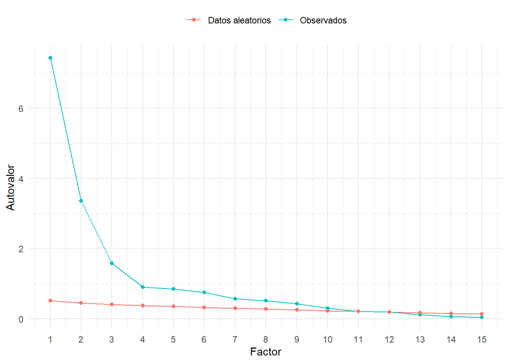

Figura 3: Análisis paralelo: autovalores observados y simulados (mitad 1, 46 ítems)

```r
tibble(factor = 1:15,
       Observados = pa$fa.values[1:15],
       `Datos aleatorios` = pa$fa.sim[1:15]) %>%
  pivot_longer(-factor, names_to = "serie", values_to = "autovalor") %>%
  ggplot(aes(factor, autovalor, colour = serie)) +
  geom_line() +
  geom_point() +
  scale_x_continuous(breaks = 1:15) +
  labs(x = "Factor", y = "Autovalor", colour = NULL) +
  theme_minimal() +
  theme(legend.position = "top")
```

Se comparan las soluciones de 3 a 8 factores con extracción por residuos mínimos (*minres*) y rotación oblicua (*oblimin*), porque se esperan factores correlacionados.

**Código**

```r
comparar_k <- map_dfr(3:8, function(k) {
  f <- fa(R_m1, nfactors = k, n.obs = nrow(mitad1), fm = "minres", rotate = "oblimin")
  L <- abs(unclass(f$loadings))
  tibble(
    factores = k,
    TLI = f$TLI,
    RMSEA = f$RMSEA[1],
    RMSR = f$rms,
    items_carga_040 = sum(apply(L, 1, max) >= 0.40),
    items_cruzados = sum(apply(L >= 0.30, 1, sum) >= 2)
  )
})

comparar_k %>%
  kable(digits = 3,
        col.names = c("Factores", "TLI", "RMSEA", "RMSR",
                      "Ítems con carga ≥ 0,40", "Ítems con cargas cruzadas"),
        caption = "Soluciones exploratorias con los 46 ítems") %>%
  kable_styling(full_width = FALSE)
```

Soluciones exploratorias con los 46 ítems

| Factores | TLI | RMSEA | RMSR | Ítems con carga ≥ 0,40 | Ítems con cargas cruzadas |
| --- | --- | --- | --- | --- | --- |
| 3 | 0.658 | 0.069 | 0.055 | 28 | 8 |
| 4 | 0.691 | 0.065 | 0.050 | 29 | 7 |
| 5 | 0.710 | 0.063 | 0.045 | 30 | 9 |
| 6 | 0.738 | 0.060 | 0.040 | 30 | 2 |
| 7 | 0.754 | 0.058 | 0.037 | 31 | 4 |
| 8 | 0.779 | 0.055 | 0.033 | 31 | 3 |

Ninguna solución con los 46 ítems ajusta bien, y en todas cerca de un tercio de los ítems no carga al menos 0,40 en ningún factor. Se adopta la **solución de 5 factores** como punto de partida porque es la más interpretable y la más cercana a las dimensiones de la propuesta. El número final se contrasta en el AFC.

# 7. Depuración de ítems (mitad 1)

Se eliminan, de uno en uno, los ítems que no cumplen dos criterios: carga máxima de al menos 0,40 y ausencia de cargas cruzadas (carga de 0,30 o más en dos o más factores). En cada paso se elimina el ítem con la carga máxima más baja y se reestima el modelo.

**Código**

```r
k_afe <- 5

depurar <- function(R, vars, k, n_obs) {
  registro <- tibble()
  repeat {
    f <- fa(R[vars, vars], nfactors = k, n.obs = n_obs,
            fm = "minres", rotate = "oblimin")
    L <- abs(unclass(f$loadings))
    carga_max <- apply(L, 1, max)
    cruzadas <- apply(L >= 0.30, 1, sum)
    malos <- names(carga_max)[carga_max < 0.40 | cruzadas >= 2]
    if (length(malos) == 0) return(list(vars = vars, modelo = f, registro = registro))
    peor <- malos[which.min(carga_max[malos] - 0.1 * (cruzadas[malos] >= 2))]
    registro <- bind_rows(registro, tibble(
      paso = nrow(registro) + 1,
      item = peor,
      carga_max = carga_max[peor],
      n_cargas_030 = cruzadas[peor],
      motivo = if_else(cruzadas[peor] >= 2, "Carga cruzada", "Carga máxima < 0,40")
    ))
    vars <- setdiff(vars, peor)
  }
}

afe <- depurar(R_m1, names(items), k_afe, nrow(mitad1))

afe$registro %>%
  mutate(enunciado = etiquetas[item], .after = item) %>%
  kable(digits = 2,
        col.names = c("Paso", "Ítem", "Enunciado", "Carga máxima",
                      "N° de cargas ≥ 0,30", "Motivo"),
        caption = "Ítems eliminados en la depuración, en orden") %>%
  kable_styling(bootstrap_options = c("striped", "condensed"))
```

Ítems eliminados en la depuración, en orden

| Paso | Ítem | Enunciado | Carga máxima | N° de cargas ≥ 0,30 | Motivo |
| --- | --- | --- | --- | --- | --- |
| 1 | O4_9 | Consumir menos es mejor que reciclar | 0.10 | 0 | Carga máxima < 0,40 |
| 2 | O4_10 | Con la vida apurada de hoy, es mejor comprar algo nuevo que reparar algo que no funciona | 0.19 | 0 | Carga máxima < 0,40 |
| 3 | O2_6 | Separa la basura de su hogar para reciclaje. | 0.34 | 2 | Carga cruzada |
| 4 | O3_10 | Compra en pequeños negocios | 0.24 | 0 | Carga máxima < 0,40 |
| 5 | O1_5 | Compra ropa de segunda mano | 0.24 | 0 | Carga máxima < 0,40 |
| 6 | O4_11 | Lo que compramos o dejamos de comprar es un problema de cada persona | 0.29 | 0 | Carga máxima < 0,40 |
| 7 | O2_10 | Lee la etiqueta de los productos antes de decidir compra. | 0.40 | 2 | Carga cruzada |
| 8 | O1_7 | Repara su ropa, accesorios y/o electrodomésticos | 0.32 | 1 | Carga máxima < 0,40 |
| 9 | O1_2 | Viaja fuera del país en avión | 0.40 | 2 | Carga cruzada |
| 10 | O4_4 | No tengo tiempo para hacerme cargo de todo lo que implica reciclar | 0.29 | 0 | Carga máxima < 0,40 |
| 11 | O2_7 | Re-utiliza papel en la impresión de documentos. | 0.33 | 1 | Carga máxima < 0,40 |
| 12 | O3_6 | Realiza un reclamo en el lugar de venta cuando un producto o servicio no lo satisface | 0.34 | 1 | Carga máxima < 0,40 |
| 13 | O4_12 | Me considero más un ciudadano que un consumidor | 0.33 | 1 | Carga máxima < 0,40 |
| 14 | O1_4 | Usa Uber, Rappi o Pedidos Ya | 0.37 | 1 | Carga máxima < 0,40 |
| 15 | O1_3 | Ve alguna serie o película en Netflix, Youtube o similar | 0.36 | 1 | Carga máxima < 0,40 |
| 16 | O1_1 | Compra algún producto en Amazon, Ali Express, E-Bay, Wish u otra tienda fuera del país | 0.39 | 1 | Carga máxima < 0,40 |
| 17 | O2_14 | Pide la boleta de los productos que compra | 0.30 | 1 | Carga máxima < 0,40 |
| 18 | O2_13 | Comenta información sobre los productos y empresas. | 0.38 | 1 | Carga máxima < 0,40 |
| 19 | O3_1 | Deja de comprar un producto porque se ha enterado de que daña el medioambiente, aunque sea más barato. | 0.63 | 2 | Carga cruzada |

Quedan 27 de los 46 ítems. La solución depurada tiene TLI = 0.877, RMSEA = 0.054 y RMSR = 0.029.

**Código**

```r
L_afe <- unclass(afe$modelo$loadings)
factor_principal <- apply(abs(L_afe), 1, which.max)

tabla_afe <- as_tibble(L_afe, rownames = "item") %>%
  mutate(enunciado = etiquetas[item], .after = item,
         h2 = afe$modelo$communality[item],
         orden = factor_principal[item],
         carga = apply(abs(L_afe), 1, max)[item]) %>%
  arrange(orden, desc(carga)) %>%
  select(-orden, -carga)

tabla_afe %>%
  mutate(across(starts_with("MR"), ~ if_else(abs(.x) < 0.30, NA_real_, .x))) %>%
  kable(digits = 2, caption = "Matriz de patrones del AFE depurado (se omiten cargas menores a 0,30; h2 = comunalidad)") %>%
  kable_styling(bootstrap_options = c("striped", "condensed"))
```

Matriz de patrones del AFE depurado (se omiten cargas menores a 0,30; h2 = comunalidad)

| item | enunciado | h2 | MR1 | MR2 | MR5 | MR3 | MR4 |
| --- | --- | --- | --- | --- | --- | --- | --- |
| O3_8 | Participa en asociaciones de consumidores, cooperativas o grupos organizados de compradores | 0.68 | 0.79 |  |  |  |  |
| O3_3 | Uso mis redes sociales para promover productos o empresas que considero éticas o sostenibles | 0.45 | 0.66 |  |  |  |  |
| O3_4 | Compra un producto exclusivamente porque no daña el medioambiente en desmedro de otro, aunque sea más caro. | 0.51 | 0.65 |  |  |  |  |
| O3_9 | Participa en marchas o movilizaciones | 0.42 | 0.64 |  |  |  |  |
| O3_5 | Realiza un reclamo o demanda colectiva en el Sernac | 0.37 | 0.60 |  |  |  |  |
| O3_2 | Intenta influir en lo que consumen otras personas | 0.38 | 0.57 |  |  |  |  |
| O3_7 | Se informa respecto de dónde viene la ropa, alimentos y otros productos que consume | 0.47 | 0.55 |  |  |  |  |
| O2_11 | Compra productos orgánicos o naturales. | 0.48 | 0.51 |  |  |  |  |
| O2_12 | Compra productos hechos con material reciclado. | 0.44 | 0.48 |  |  |  |  |
| O1_8 | Adquiere productos con la etiqueta “comercio justo” | 0.26 | 0.44 |  |  |  |  |
| O1_6 | Cultiva y cosecha sus propios alimentos | 0.19 | 0.42 |  |  |  |  |
| O2_1 | Evita dejar luces prendidas en ambiente desocupados | 0.56 |  | 0.66 |  |  |  |
| O2_5 | Desenchufa aparatos eléctricos cuando no los está ocupando. | 0.42 |  | 0.60 |  |  |  |
| O2_2 | Corta el agua mientras se lava los dientes. | 0.39 |  | 0.55 |  |  |  |
| O2_3 | Toma duchas cortas | 0.33 |  | 0.54 |  |  |  |
| O2_4 | Espera que los alimentos se enfríen antes de guardarlos en el refrigerador. | 0.38 |  | 0.49 |  |  |  |
| O2_8 | Planifica compra de alimentos. | 0.65 |  |  | 0.75 |  |  |
| O1_10 | Elabora un presupuesto mensual para monitorear mis gastos | 0.44 |  |  | 0.66 |  |  |
| O2_9 | Planifica compras de vestuario. | 0.42 |  |  | 0.60 |  |  |
| O1_9 | Compara precios en internet antes de comprar | 0.17 |  |  | 0.42 |  |  |
| O4_3 | Es fácil llevar mi reciclaje hasta los centros de acopio | 0.82 |  |  |  | 0.91 |  |
| O4_5 | En mi comuna o barrio es fácil reciclar | 0.56 |  |  |  | 0.74 |  |
| O4_6 | En mi hogar, todos/as reciclamos | 0.33 |  |  |  | 0.44 |  |
| O4_2 | Es fácil entender el etiquetado de los envases para separar el reciclaje | 0.20 |  |  |  | 0.41 |  |
| O4_1 | Es necesario hacerse cargo de las tareas de reciclaje | 0.47 |  |  |  |  | 0.67 |
| O4_8 | Reciclar es bueno para la economía | 0.33 |  |  |  |  | 0.55 |
| O4_7 | Me cuesta creer que un envase reciclado sirva de algo para el medioambiente | 0.18 |  |  |  |  | -0.42 |

**Código**

```r
afe$modelo$Phi %>%
  kable(digits = 2, caption = "Correlaciones entre factores del AFE") %>%
  kable_styling(full_width = FALSE)
```

Correlaciones entre factores del AFE

|  | MR1 | MR2 | MR5 | MR3 | MR4 |
| --- | --- | --- | --- | --- | --- |
| MR1 | 1.00 | 0.02 | 0.26 | 0.16 | 0.00 |
| MR2 | 0.02 | 1.00 | 0.51 | 0.03 | 0.38 |
| MR5 | 0.26 | 0.51 | 1.00 | 0.09 | 0.24 |
| MR3 | 0.16 | 0.03 | 0.09 | 1.00 | 0.10 |
| MR4 | 0.00 | 0.38 | 0.24 | 0.10 | 1.00 |

**Código**

```r
set.seed(20231)
pa_dep <- fa.parallel(R_m1[afe$vars, afe$vars], n.obs = nrow(mitad1),
                      fm = "minres", fa = "fa", n.iter = 50, plot = FALSE)
```

Con los 27 ítems retenidos, el análisis paralelo sugiere 6 factores. La teoría ofrece una lectura para ese factor adicional: el primer factor podría separarse en **compra sustentable** (consumo verde) y **consumo político** (acción colectiva y discursiva), como distingue la literatura revisada. Esa hipótesis se prueba en el AFC.

# 8. Análisis factorial confirmatorio (mitad 2)

Los modelos se estiman en la mitad 2 con `lavaan`, tratando los ítems como ordinales y usando el estimador WLSMV. Antes de estimar, se invierte O4.7 (“Me cuesta creer que un envase reciclado sirva de algo para el medioambiente”) para que todos los indicadores de valoración del reciclaje apunten en el mismo sentido.

**Código**

```r
mitad2_afc <- mitad2 %>%
  mutate(O4_7 = max(O4_7) + 1 - O4_7)

estimar <- function(modelo) {
  cfa(modelo, data = mitad2_afc, ordered = TRUE, estimator = "WLSMV")
}
```

Se comparan cuatro modelos:

- **M1, unidimensional:** un factor general de consumo responsable con los 27 ítems del AFE. Es el supuesto implícito de los índices sumativos tipo Akatu.
- **M2, cinco factores:** la estructura del AFE.
- **M3, seis factores:** separa compra sustentable y consumo político.
- **M4, seis factores depurado:** M3 sin O4.6 (“En mi hogar, todos/as reciclamos”). Este ítem describe una práctica y no una condición para reciclar, y en M3 concentra los mayores índices de modificación.

**Código**

```r
m1 <- '
general =~ O1_6 + O1_8 + O2_11 + O2_12 + O3_2 + O3_3 + O3_4 + O3_5 + O3_7 +
           O3_8 + O3_9 + O2_1 + O2_2 + O2_3 + O2_4 + O2_5 + O1_9 + O1_10 +
           O2_8 + O2_9 + O4_2 + O4_3 + O4_5 + O4_6 + O4_1 + O4_7 + O4_8
'

m2 <- '
sust_politico =~ O1_6 + O1_8 + O2_11 + O2_12 + O3_2 + O3_3 + O3_4 + O3_5 +
                 O3_7 + O3_8 + O3_9
ahorro        =~ O2_1 + O2_2 + O2_3 + O2_4 + O2_5
planificacion =~ O1_9 + O1_10 + O2_8 + O2_9
facilidad_rec =~ O4_2 + O4_3 + O4_5 + O4_6
valoracion_rec =~ O4_1 + O4_7 + O4_8
'

m3 <- '
compra_sust   =~ O1_6 + O1_8 + O2_11 + O2_12 + O3_4 + O3_7
consumo_pol   =~ O3_2 + O3_3 + O3_5 + O3_8 + O3_9
ahorro        =~ O2_1 + O2_2 + O2_3 + O2_4 + O2_5
planificacion =~ O1_9 + O1_10 + O2_8 + O2_9
facilidad_rec =~ O4_2 + O4_3 + O4_5 + O4_6
valoracion_rec =~ O4_1 + O4_7 + O4_8
'

m4 <- '
compra_sust   =~ O1_6 + O1_8 + O2_11 + O2_12 + O3_4 + O3_7
consumo_pol   =~ O3_2 + O3_3 + O3_5 + O3_8 + O3_9
ahorro        =~ O2_1 + O2_2 + O2_3 + O2_4 + O2_5
planificacion =~ O1_9 + O1_10 + O2_8 + O2_9
facilidad_rec =~ O4_2 + O4_3 + O4_5
valoracion_rec =~ O4_1 + O4_7 + O4_8
'

ajustes <- list(
  "M1 Unidimensional"         = estimar(m1),
  "M2 Cinco factores (AFE)"   = estimar(m2),
  "M3 Seis factores"          = estimar(m3),
  "M4 Seis factores, sin O4.6" = estimar(m4)
)
```

## Ajuste de los modelos

Criterios convencionales para buen ajuste: CFI y TLI ≥ 0,95 (aceptable ≥ 0,90), RMSEA ≤ 0,06 (aceptable ≤ 0,08) y SRMR ≤ 0,08. Se reportan los índices escalados (robustos).

**Código**

```r
indices <- c("chisq.scaled", "df", "pvalue.scaled", "cfi.scaled", "tli.scaled",
             "rmsea.scaled", "rmsea.ci.lower.scaled", "rmsea.ci.upper.scaled", "srmr")

tabla_ajuste <- imap_dfr(ajustes, ~ as_tibble_row(fitMeasures(.x, indices)) %>%
                           mutate(modelo = .y, .before = 1)) %>%
  mutate(across(-modelo, as.numeric),
         n_items = map_int(ajustes, ~ length(lavNames(.x, "ov"))), .after = modelo)

tabla_ajuste %>%
  mutate(rmsea_ic = sprintf("[%.3f; %.3f]", rmsea.ci.lower.scaled, rmsea.ci.upper.scaled),
         pvalue.scaled = if_else(pvalue.scaled < 0.001, "< 0,001",
                                 formatC(pvalue.scaled, digits = 3))) %>%
  select(modelo, n_items, chisq.scaled, df, pvalue.scaled, cfi.scaled, tli.scaled,
         rmsea.scaled, rmsea_ic, srmr) %>%
  kable(digits = 3, format.args = list(big.mark = "."),
        col.names = c("Modelo", "Ítems", "χ² escalado", "gl", "p", "CFI", "TLI",
                      "RMSEA", "IC 90% RMSEA", "SRMR"),
        caption = "Índices de ajuste de los modelos confirmatorios (mitad 2, WLSMV)") %>%
  kable_styling(bootstrap_options = c("striped", "condensed"))
```

Índices de ajuste de los modelos confirmatorios (mitad 2, WLSMV)

| Modelo | Ítems | χ² escalado | gl | p | CFI | TLI | RMSEA | IC 90% RMSEA | SRMR |
| --- | --- | --- | --- | --- | --- | --- | --- | --- | --- |
| M1 Unidimensional | 27 | 3.991.197 | 324 | < 0,001 | 0.439 | 0.392 | 0.118 | [0.115; 0.121] | 0.134 |
| M2 Cinco factores (AFE) | 27 | 1.560.880 | 314 | < 0,001 | 0.809 | 0.787 | 0.070 | [0.067; 0.073] | 0.088 |
| M3 Seis factores | 27 | 1.067.664 | 309 | < 0,001 | 0.884 | 0.868 | 0.055 | [0.051; 0.059] | 0.069 |
| M4 Seis factores, sin O4.6 | 26 | 843.646 | 284 | < 0,001 | 0.910 | 0.897 | 0.049 | [0.045; 0.053] | 0.064 |

M2 está anidado en M3: equivale a fijar en 1 la correlación entre compra sustentable y consumo político. La diferencia se contrasta con la prueba de χ² escalada.

**Código**

```r
lavTestLRT(ajustes[["M3 Seis factores"]], ajustes[["M2 Cinco factores (AFE)"]]) %>%
  as.data.frame() %>%
  mutate(Modelo = c("M3 Seis factores", "M2 Cinco factores (AFE)"), .before = 1) %>%
  select(Modelo, Df, `Chisq diff`, `Df diff`, `Pr(>Chisq)`) %>%
  mutate(`Pr(>Chisq)` = if_else(`Pr(>Chisq)` < 0.001, "< 0,001",
                                formatC(`Pr(>Chisq)`, digits = 3))) %>%
  kable(digits = 2, row.names = FALSE,
        col.names = c("Modelo", "gl", "Diferencia χ² escalada", "Diferencia gl", "p"),
        caption = "Prueba de diferencia de χ² escalada (Satorra, 2000): M3 frente a M2") %>%
  kable_styling(full_width = FALSE)
```

Prueba de diferencia de χ² escalada (Satorra, 2000): M3 frente a M2

| Modelo | gl | Diferencia χ² escalada | Diferencia gl | p |
| --- | --- | --- | --- | --- |
| M3 Seis factores | 309 |  |  |  |
| M2 Cinco factores (AFE) | 314 | 240.72 | 5 | < 0,001 |

El modelo unidimensional se descarta: su ajuste es muy deficiente. Separar compra sustentable y consumo político (M3) mejora significativamente el ajuste respecto de M2. M4 es el mejor modelo: su RMSEA y su SRMR están en rango de buen ajuste, aunque el CFI y el TLI quedan en torno a 0,90, bajo el umbral estricto de 0,95.

## Modelo final (M4)

**Código**

```r
fit_final <- ajustes[["M4 Seis factores, sin O4.6"]]
sol <- standardizedSolution(fit_final)

cargas <- sol %>%
  filter(op == "=~") %>%
  transmute(factor = lhs, item = rhs, enunciado = etiquetas[rhs],
            carga = est.std, ee = se, p = pvalue)

cargas %>%
  mutate(p = if_else(p < 0.001, "< 0,001", formatC(p, digits = 3))) %>%
  kable(digits = 2,
        col.names = c("Factor", "Ítem", "Enunciado", "Carga estandarizada", "EE", "p"),
        caption = "Cargas factoriales estandarizadas del modelo M4") %>%
  kable_styling(bootstrap_options = c("striped", "condensed")) %>%
  collapse_rows(columns = 1, valign = "top")
```

Cargas factoriales estandarizadas del modelo M4

| Factor | Ítem | Enunciado | Carga estandarizada | EE | p |
| --- | --- | --- | --- | --- | --- |
| compra_sust | O1_6 | Cultiva y cosecha sus propios alimentos | 0.39 | 0.04 | < 0,001 |
|  | O1_8 | Adquiere productos con la etiqueta “comercio justo” | 0.45 | 0.03 | < 0,001 |
|  | O2_11 | Compra productos orgánicos o naturales. | 0.63 | 0.03 | < 0,001 |
|  | O2_12 | Compra productos hechos con material reciclado. | 0.68 | 0.03 | < 0,001 |
|  | O3_4 | Compra un producto exclusivamente porque no daña el medioambiente en desmedro de otro, aunque sea más caro. | 0.71 | 0.03 | < 0,001 |
|  | O3_7 | Se informa respecto de dónde viene la ropa, alimentos y otros productos que consume | 0.65 | 0.03 | < 0,001 |
| consumo_pol | O3_2 | Intenta influir en lo que consumen otras personas | 0.68 | 0.03 | < 0,001 |
|  | O3_3 | Uso mis redes sociales para promover productos o empresas que considero éticas o sostenibles | 0.81 | 0.02 | < 0,001 |
|  | O3_5 | Realiza un reclamo o demanda colectiva en el Sernac | 0.58 | 0.03 | < 0,001 |
|  | O3_8 | Participa en asociaciones de consumidores, cooperativas o grupos organizados de compradores | 0.74 | 0.03 | < 0,001 |
|  | O3_9 | Participa en marchas o movilizaciones | 0.59 | 0.04 | < 0,001 |
| ahorro | O2_1 | Evita dejar luces prendidas en ambiente desocupados | 0.73 | 0.03 | < 0,001 |
|  | O2_2 | Corta el agua mientras se lava los dientes. | 0.66 | 0.04 | < 0,001 |
|  | O2_3 | Toma duchas cortas | 0.61 | 0.03 | < 0,001 |
|  | O2_4 | Espera que los alimentos se enfríen antes de guardarlos en el refrigerador. | 0.57 | 0.04 | < 0,001 |
|  | O2_5 | Desenchufa aparatos eléctricos cuando no los está ocupando. | 0.64 | 0.03 | < 0,001 |
| planificacion | O1_9 | Compara precios en internet antes de comprar | 0.37 | 0.04 | < 0,001 |
|  | O1_10 | Elabora un presupuesto mensual para monitorear mis gastos | 0.65 | 0.03 | < 0,001 |
|  | O2_8 | Planifica compra de alimentos. | 0.76 | 0.03 | < 0,001 |
|  | O2_9 | Planifica compras de vestuario. | 0.54 | 0.04 | < 0,001 |
| facilidad_rec | O4_2 | Es fácil entender el etiquetado de los envases para separar el reciclaje | 0.37 | 0.04 | < 0,001 |
|  | O4_3 | Es fácil llevar mi reciclaje hasta los centros de acopio | 0.87 | 0.05 | < 0,001 |
|  | O4_5 | En mi comuna o barrio es fácil reciclar | 0.82 | 0.04 | < 0,001 |
| valoracion_rec | O4_1 | Es necesario hacerse cargo de las tareas de reciclaje | 0.67 | 0.05 | < 0,001 |
|  | O4_7 | Me cuesta creer que un envase reciclado sirva de algo para el medioambiente | 0.43 | 0.05 | < 0,001 |
|  | O4_8 | Reciclar es bueno para la economía | 0.52 | 0.05 | < 0,001 |

**Código**

```r
cor_factores <- lavInspect(fit_final, "cor.lv")

cor_factores %>%
  kable(digits = 2, caption = "Correlaciones entre factores latentes del modelo M4") %>%
  kable_styling(full_width = FALSE)
```

Correlaciones entre factores latentes del modelo M4

|  | compra_sust | consumo_pol | ahorro | planificacion | facilidad_rec | valoracion_rec |
| --- | --- | --- | --- | --- | --- | --- |
| compra_sust | 1.00 | 0.69 | 0.39 | 0.55 | 0.18 | 0.25 |
| consumo_pol | 0.69 | 1.00 | -0.13 | 0.24 | 0.16 | -0.08 |
| ahorro | 0.39 | -0.13 | 1.00 | 0.58 | -0.06 | 0.50 |
| planificacion | 0.55 | 0.24 | 0.58 | 1.00 | 0.01 | 0.28 |
| facilidad_rec | 0.18 | 0.16 | -0.06 | 0.01 | 1.00 | 0.02 |
| valoracion_rec | 0.25 | -0.08 | 0.50 | 0.28 | 0.02 | 1.00 |

## Confiabilidad

Para cada factor se calcula la confiabilidad compuesta (omega) a partir de las cargas estandarizadas, y la varianza media extraída (AVE). Se considera adecuado un omega de al menos 0,70; la AVE idealmente supera 0,50.

**Código**

```r
confiabilidad <- cargas %>%
  group_by(factor) %>%
  summarise(
    n_items = n(),
    omega = sum(carga)^2 / (sum(carga)^2 + sum(1 - carga^2)),
    AVE = mean(carga^2),
    .groups = "drop"
  )

confiabilidad %>%
  kable(digits = 2, col.names = c("Factor", "Ítems", "Omega", "AVE"),
        caption = "Confiabilidad compuesta y varianza media extraída (modelo M4)") %>%
  kable_styling(full_width = FALSE)
```

Confiabilidad compuesta y varianza media extraída (modelo M4)

| Factor | Ítems | Omega | AVE |
| --- | --- | --- | --- |
| ahorro | 5 | 0.78 | 0.41 |
| compra_sust | 6 | 0.76 | 0.36 |
| consumo_pol | 5 | 0.81 | 0.47 |
| facilidad_rec | 3 | 0.75 | 0.53 |
| planificacion | 4 | 0.67 | 0.35 |
| valoracion_rec | 3 | 0.56 | 0.30 |

## Índices de modificación

Los diez mayores índices de modificación del modelo final. Se muestran como diagnóstico; el modelo no se reespecifica a partir de ellos para no ajustarlo a esta muestra.

**Código**

```r
modindices(fit_final, sort. = TRUE, maximum.number = 10) %>%
  as_tibble() %>%
  select(lhs, op, rhs, mi, epc, sepc.all) %>%
  kable(digits = 2, col.names = c("", "", "", "IM", "Cambio esperado", "Cambio estandarizado"),
        caption = "Mayores índices de modificación del modelo M4") %>%
  kable_styling(full_width = FALSE)
```

Mayores índices de modificación del modelo M4

|  |  |  | IM | Cambio esperado | Cambio estandarizado |
| --- | --- | --- | --- | --- | --- |
| consumo_pol | =~ | O2_9 | 84.32 | 0.37 | 0.25 |
| consumo_pol | =~ | O2_8 | 80.36 | -0.44 | -0.29 |
| valoracion_rec | =~ | O3_8 | 77.51 | -0.55 | -0.37 |
| ahorro | =~ | O2_8 | 66.10 | 0.61 | 0.45 |
| compra_sust | =~ | O2_8 | 65.53 | -1.01 | -0.40 |
| ahorro | =~ | O3_8 | 64.66 | -0.34 | -0.25 |
| ahorro | =~ | O2_9 | 64.59 | -0.51 | -0.37 |
| compra_sust | =~ | O3_3 | 64.32 | 0.95 | 0.37 |
| compra_sust | =~ | O3_8 | 61.59 | -1.00 | -0.39 |
| compra_sust | =~ | O2_9 | 60.87 | 0.77 | 0.30 |

# 9. Modelos de medida reducidos

El modelo M4 cubre muchas dimensiones, pero su CFI queda bajo 0,95 y dos de sus factores tienen confiabilidad insuficiente. Esta sección busca un objetivo distinto: modelos más acotados que midan **bien** al menos algunas dimensiones, aunque se pierdan ítems.

## Selección estricta de ítems (mitad 1)

Se repite la depuración del AFE con criterios más exigentes: carga mínima de **0,50**, sin cargas cruzadas, y se revisa que cada factor conserve al menos tres ítems. La selección se hace solo con la mitad 1.

**Código**

```r
depurar_estricto <- function(R, vars, k, n_obs, umbral = 0.50) {
  repeat {
    f <- fa(R[vars, vars], nfactors = k, n.obs = n_obs,
            fm = "minres", rotate = "oblimin")
    L <- abs(unclass(f$loadings))
    carga_max <- apply(L, 1, max)
    cruzadas <- apply(L >= 0.30, 1, sum)
    malos <- names(carga_max)[carga_max < umbral | cruzadas >= 2]
    if (length(malos) == 0) return(list(vars = vars, modelo = f))
    peor <- malos[which.min(carga_max[malos] - 0.1 * (cruzadas[malos] >= 2))]
    vars <- setdiff(vars, peor)
  }
}

estrictos <- map(3:5, function(k) {
  r <- depurar_estricto(R_m1, names(items), k, nrow(mitad1))
  L <- unclass(r$modelo$loadings)
  prim <- apply(abs(L), 1, which.max)
  tibble(
    factores = k,
    factor = paste0("F", prim),
    item = names(prim),
    carga = L[cbind(seq_along(prim), prim)]
  )
}) %>% bind_rows()

estrictos %>%
  group_by(factores, factor) %>%
  summarise(n_items = n(),
            items = paste0(item, " (", formatC(carga, digits = 2, format = "f"), ")",
                           collapse = ", "),
            .groups = "drop") %>%
  kable(col.names = c("Solución", "Factor", "N° ítems", "Ítems (carga)"),
        caption = "Factores que sobreviven a la depuración estricta, por número de factores (mitad 1)") %>%
  kable_styling(bootstrap_options = c("striped", "condensed")) %>%
  collapse_rows(columns = 1, valign = "top")
```

Factores que sobreviven a la depuración estricta, por número de factores (mitad 1)

| Solución | Factor | N° ítems | Ítems (carga) |
| --- | --- | --- | --- |
| 3 | F1 | 6 | O2_1 (0.72), O2_2 (0.61), O2_3 (0.57), O2_4 (0.61), O2_5 (0.63), O2_8 (0.58) |
|  | F2 | 5 | O3_2 (0.56), O3_3 (0.65), O3_5 (0.61), O3_8 (0.83), O3_9 (0.64) |
|  | F3 | 2 | O4_3 (0.89), O4_5 (0.77) |
| 4 | F1 | 7 | O3_2 (0.59), O3_3 (0.65), O3_4 (0.59), O3_5 (0.59), O3_7 (0.55), O3_8 (0.82), O3_9 (0.67) |
|  | F2 | 3 | O1_10 (0.61), O2_8 (0.83), O2_9 (0.59) |
|  | F3 | 2 | O4_3 (0.93), O4_5 (0.74) |
|  | F4 | 2 | O4_1 (0.72), O4_8 (0.57) |
| 5 | F1 | 7 | O3_2 (0.56), O3_3 (0.65), O3_4 (0.62), O3_5 (0.59), O3_7 (0.56), O3_8 (0.82), O3_9 (0.66) |
|  | F2 | 3 | O1_10 (0.65), O2_8 (0.77), O2_9 (0.61) |
|  | F3 | 2 | O4_3 (0.92), O4_5 (0.75) |
|  | F4 | 3 | O2_1 (0.69), O2_2 (0.55), O2_5 (0.63) |
|  | F5 | 2 | O4_1 (0.70), O4_8 (0.55) |

- **Consumo crítico y político:** O3.2, O3.3, O3.4, O3.5, O3.7, O3.8 y O3.9.
- **Ahorro doméstico:** O2.1 a O2.5.
- **Planificación de compras:** O1.10, O2.8 y O2.9.

Las dimensiones de reciclaje solo retienen dos ítems cada una (O4.3 y O4.5 para facilidad; O4.1 y O4.8 para valoración), insuficiente para un factor confiable.

## Validación de modelos candidatos (mitad 2)

Con esos núcleos se especifican modelos candidatos y se estiman en la mitad 2. El factor de consumo crítico se prueba entero y también separado en sus dos componentes teóricos, compra sustentable y consumo político, tal como en la sección 8. Para compra sustentable se suman O2.11 y O2.12 (productos orgánicos y reciclados), que en el AFE de la sección 7 cargaban en el mismo factor.

**Código**

```r
f_pol    <- "consumo_pol =~ O3_2 + O3_3 + O3_5 + O3_8 + O3_9"
f_sust   <- "compra_sust =~ O2_11 + O2_12 + O3_4 + O3_7"
f_crit   <- "critico =~ O3_2 + O3_3 + O3_4 + O3_5 + O3_7 + O3_8 + O3_9"
f_crit9  <- "critico =~ O2_11 + O2_12 + O3_4 + O3_7 + O3_2 + O3_3 + O3_5 + O3_8 + O3_9"
f_ahorro <- "ahorro =~ O2_1 + O2_2 + O2_3 + O2_4 + O2_5"
f_plan   <- "planificacion =~ O1_10 + O2_8 + O2_9"

juntar <- function(...) paste(..., sep = "\n")

candidatos <- list(
  "R1 Consumo crítico (7 ítems, 1 factor)"            = f_crit,
  "R2 Consumo sustentable y político (9 ítems, 1 factor)" = f_crit9,
  "R3 Compra sustentable + consumo político"           = juntar(f_sust, f_pol),
  "R4 Ahorro doméstico"                                = f_ahorro,
  "R5 Ahorro + planificación"                          = juntar(f_ahorro, f_plan),
  "R6 R3 + R5 en un solo modelo"                       = juntar(f_sust, f_pol, f_ahorro, f_plan)
)

ajustes_red <- map(candidatos, estimar)

omega_ave <- function(fit) {
  standardizedSolution(fit) %>%
    filter(op == "=~") %>%
    group_by(factor = lhs) %>%
    summarise(n_items = n(),
              omega = sum(est.std)^2 / (sum(est.std)^2 + sum(1 - est.std^2)),
              AVE = mean(est.std^2),
              carga_min = min(est.std),
              .groups = "drop")
}

tabla_red <- imap_dfr(ajustes_red, function(f, nombre) {
  fm <- fitMeasures(f, indices)
  conf <- omega_ave(f)
  tibble(modelo = nombre,
         n_items = length(lavNames(f, "ov")),
         chi2 = fm["chisq.scaled"], gl = fm["df"],
         CFI = fm["cfi.scaled"], TLI = fm["tli.scaled"],
         RMSEA = fm["rmsea.scaled"], SRMR = fm["srmr"],
         omega_min = min(conf$omega))
})

tabla_red %>%
  kable(digits = 3, format.args = list(big.mark = "."),
        col.names = c("Modelo", "Ítems", "χ² escalado", "gl", "CFI", "TLI",
                      "RMSEA", "SRMR", "Omega mínimo"),
        caption = "Ajuste y confiabilidad de los modelos reducidos (mitad 2, WLSMV)") %>%
  kable_styling(bootstrap_options = c("striped", "condensed"))
```

Ajuste y confiabilidad de los modelos reducidos (mitad 2, WLSMV)

| Modelo | Ítems | χ² escalado | gl | CFI | TLI | RMSEA | SRMR | Omega mínimo |
| --- | --- | --- | --- | --- | --- | --- | --- | --- |
| R1 Consumo crítico (7 ítems, 1 factor) | 7 | 122.604 | 14 | 0.943 | 0.915 | 0.098 | 0.064 | 0.831 |
| R2 Consumo sustentable y político (9 ítems, 1 factor) | 9 | 325.375 | 27 | 0.886 | 0.848 | 0.117 | 0.090 | 0.847 |
| R3 Compra sustentable + consumo político | 9 | 110.899 | 26 | 0.968 | 0.955 | 0.063 | 0.049 | 0.767 |
| R4 Ahorro doméstico | 5 | 4.616 | 5 | 1.000 | 1.001 | 0.000 | 0.015 | 0.778 |
| R5 Ahorro + planificación | 8 | 28.701 | 19 | 0.995 | 0.992 | 0.025 | 0.027 | 0.697 |
| R6 R3 + R5 en un solo modelo | 17 | 442.475 | 113 | 0.925 | 0.910 | 0.060 | 0.066 | 0.691 |

Dos modelos cumplen los criterios de buen ajuste:

- **R3, compra sustentable y consumo político.** CFI y TLI sobre 0,95 y SRMR bajo 0,05; el RMSEA queda en el límite de 0,06. Separar los dos factores es necesario: el mismo conjunto de ítems como un solo factor (R2) ajusta mal.
- **R5, ahorro doméstico y planificación de compras.**

Combinar ambos en un solo modelo (R6) empeora el ajuste. Las prácticas de la esfera doméstica y las de la esfera pública se miden mejor como bloques separados.

## Distinción entre compra sustentable y consumo político

**Código**

```r
fit_r3 <- ajustes_red[["R3 Compra sustentable + consumo político"]]
fit_r2 <- ajustes_red[["R2 Consumo sustentable y político (9 ítems, 1 factor)"]]

lavTestLRT(fit_r3, fit_r2) %>%
  as.data.frame() %>%
  mutate(Modelo = c("R3 Dos factores", "R2 Un factor"), .before = 1) %>%
  select(Modelo, Df, `Chisq diff`, `Df diff`, `Pr(>Chisq)`) %>%
  mutate(`Pr(>Chisq)` = if_else(`Pr(>Chisq)` < 0.001, "< 0,001",
                                formatC(`Pr(>Chisq)`, digits = 3))) %>%
  kable(digits = 2, row.names = FALSE,
        col.names = c("Modelo", "gl", "Diferencia χ² escalada", "Diferencia gl", "p"),
        caption = "Prueba de diferencia de χ²: dos factores frente a uno") %>%
  kable_styling(full_width = FALSE)
```

Prueba de diferencia de χ²: dos factores frente a uno

| Modelo | gl | Diferencia χ² escalada | Diferencia gl | p |
| --- | --- | --- | --- | --- |
| R3 Dos factores | 26 |  |  |  |
| R2 Un factor | 27 | 98.84 | 1 | < 0,001 |

**Código**

```r
cor_r3 <- standardizedSolution(fit_r3) %>%
  filter(op == "~~", lhs == "compra_sust", rhs == "consumo_pol")
```

La correlación entre compra sustentable y consumo político es 0.66 (IC 95%: 0.59 a 0.72). Están relacionados, pero el intervalo queda lejos de 1, por lo que se trata de dimensiones distintas.

## Estabilidad del ajuste

Los dos modelos se reestiman en la mitad 1 y en la muestra completa. Si el ajuste se mantiene, no depende de la mitad usada para validarlo.

**Código**

```r
modelos_finales <- list(
  "R3 Compra sustentable + consumo político" = candidatos[["R3 Compra sustentable + consumo político"]],
  "R5 Ahorro + planificación"                = candidatos[["R5 Ahorro + planificación"]]
)

muestras <- list("Mitad 1" = mitad1, "Mitad 2" = mitad2, "Muestra completa" = items)

estabilidad <- imap_dfr(modelos_finales, function(m, nombre_m) {
  imap_dfr(muestras, function(d, nombre_d) {
    f <- cfa(m, data = d, ordered = TRUE, estimator = "WLSMV")
    fm <- fitMeasures(f, indices)
    tibble(modelo = nombre_m, muestra = nombre_d, n = nrow(d),
           CFI = fm["cfi.scaled"], TLI = fm["tli.scaled"],
           RMSEA = fm["rmsea.scaled"],
           RMSEA_ic = sprintf("[%.3f; %.3f]", fm["rmsea.ci.lower.scaled"],
                              fm["rmsea.ci.upper.scaled"]),
           SRMR = fm["srmr"])
  })
})

estabilidad %>%
  kable(digits = 3, col.names = c("Modelo", "Muestra", "N", "CFI", "TLI",
                                  "RMSEA", "IC 90% RMSEA", "SRMR"),
        caption = "Ajuste de los modelos reducidos en distintas muestras") %>%
  kable_styling(bootstrap_options = c("striped", "condensed")) %>%
  collapse_rows(columns = 1, valign = "top")
```

Ajuste de los modelos reducidos en distintas muestras

| Modelo | Muestra | N | CFI | TLI | RMSEA | IC 90% RMSEA | SRMR |
| --- | --- | --- | --- | --- | --- | --- | --- |
| R3 Compra sustentable + consumo político | Mitad 1 | 811 | 0.974 | 0.965 | 0.058 | [0.046; 0.071] | 0.045 |
|  | Mitad 2 | 812 | 0.968 | 0.955 | 0.063 | [0.052; 0.076] | 0.049 |
|  | Muestra completa | 1623 | 0.971 | 0.959 | 0.061 | [0.053; 0.070] | 0.045 |
| R5 Ahorro + planificación | Mitad 1 | 811 | 0.982 | 0.974 | 0.046 | [0.032; 0.062] | 0.038 |
|  | Mitad 2 | 812 | 0.995 | 0.992 | 0.025 | [0.000; 0.043] | 0.027 |
|  | Muestra completa | 1623 | 0.988 | 0.983 | 0.037 | [0.027; 0.048] | 0.029 |

## Cargas y confiabilidad de los modelos reducidos (muestra completa)

Las estimaciones finales se presentan con la muestra completa (N = 1623), una vez validada la estructura.

**Código**

```r
items_afc <- items %>% mutate(O4_7 = max(O4_7) + 1 - O4_7)

fits_finales <- map(modelos_finales, ~ cfa(.x, data = items_afc, ordered = TRUE,
                                            estimator = "WLSMV"))

cargas_red <- imap_dfr(fits_finales, function(f, nombre) {
  standardizedSolution(f) %>%
    filter(op == "=~") %>%
    transmute(modelo = nombre, factor = lhs, item = rhs,
              enunciado = etiquetas[rhs], carga = est.std, ee = se)
})

cargas_red %>%
  select(-modelo) %>%
  kable(digits = 2,
        col.names = c("Factor", "Ítem", "Enunciado", "Carga estandarizada", "EE"),
        caption = "Cargas estandarizadas de los modelos reducidos (muestra completa)") %>%
  kable_styling(bootstrap_options = c("striped", "condensed")) %>%
  collapse_rows(columns = 1, valign = "top")
```

Cargas estandarizadas de los modelos reducidos (muestra completa)

| Factor | Ítem | Enunciado | Carga estandarizada | EE |
| --- | --- | --- | --- | --- |
| compra_sust | O2_11 | Compra productos orgánicos o naturales. | 0.65 | 0.02 |
|  | O2_12 | Compra productos hechos con material reciclado. | 0.62 | 0.02 |
|  | O3_4 | Compra un producto exclusivamente porque no daña el medioambiente en desmedro de otro, aunque sea más caro. | 0.75 | 0.02 |
|  | O3_7 | Se informa respecto de dónde viene la ropa, alimentos y otros productos que consume | 0.67 | 0.02 |
| consumo_pol | O3_2 | Intenta influir en lo que consumen otras personas | 0.65 | 0.02 |
|  | O3_3 | Uso mis redes sociales para promover productos o empresas que considero éticas o sostenibles | 0.77 | 0.02 |
|  | O3_5 | Realiza un reclamo o demanda colectiva en el Sernac | 0.59 | 0.02 |
|  | O3_8 | Participa en asociaciones de consumidores, cooperativas o grupos organizados de compradores | 0.74 | 0.02 |
|  | O3_9 | Participa en marchas o movilizaciones | 0.61 | 0.03 |
| ahorro | O2_1 | Evita dejar luces prendidas en ambiente desocupados | 0.73 | 0.02 |
|  | O2_2 | Corta el agua mientras se lava los dientes. | 0.63 | 0.03 |
|  | O2_3 | Toma duchas cortas | 0.60 | 0.02 |
|  | O2_4 | Espera que los alimentos se enfríen antes de guardarlos en el refrigerador. | 0.59 | 0.03 |
|  | O2_5 | Desenchufa aparatos eléctricos cuando no los está ocupando. | 0.62 | 0.02 |
| planificacion | O1_10 | Elabora un presupuesto mensual para monitorear mis gastos | 0.60 | 0.02 |
|  | O2_8 | Planifica compra de alimentos. | 0.90 | 0.03 |
|  | O2_9 | Planifica compras de vestuario. | 0.48 | 0.02 |

**Código**

```r
confiabilidad_red <- imap_dfr(fits_finales, ~ omega_ave(.x) %>% mutate(modelo = .y, .before = 1))

confiabilidad_red %>%
  kable(digits = 2,
        col.names = c("Modelo", "Factor", "Ítems", "Omega", "AVE", "Carga mínima"),
        caption = "Confiabilidad compuesta y varianza media extraída (muestra completa)") %>%
  kable_styling(full_width = FALSE) %>%
  collapse_rows(columns = 1, valign = "top")
```

Confiabilidad compuesta y varianza media extraída (muestra completa)

| Modelo | Factor | Ítems | Omega | AVE | Carga mínima |
| --- | --- | --- | --- | --- | --- |
| R3 Compra sustentable + consumo político | compra_sust | 4 | 0.77 | 0.46 | 0.62 |
|  | consumo_pol | 5 | 0.80 | 0.45 | 0.59 |
| R5 Ahorro + planificación | ahorro | 5 | 0.77 | 0.40 | 0.59 |
|  | planificacion | 3 | 0.71 | 0.47 | 0.48 |

**Código**

```r
cor_r5 <- lavInspect(fits_finales[["R5 Ahorro + planificación"]], "cor.lv")
```

En el modelo R5, ahorro doméstico y planificación de compras se correlacionan en 0.59.

## Modelo conjunto: relaciones entre bloques

¿Por qué dos modelos y no uno con los cuatro factores? Para responderlo se estima el modelo conjunto (R6) en las tres muestras y se examina dónde se concentra su desajuste.

**Código**

```r
m_conjunto <- candidatos[["R6 R3 + R5 en un solo modelo"]]

conjunto_ajuste <- imap_dfr(muestras, function(d, nombre_d) {
  f <- cfa(m_conjunto, data = d, ordered = TRUE, estimator = "WLSMV")
  fm <- fitMeasures(f, indices)
  tibble(muestra = nombre_d, n = nrow(d),
         CFI = fm["cfi.scaled"], TLI = fm["tli.scaled"],
         RMSEA = fm["rmsea.scaled"], SRMR = fm["srmr"])
})

conjunto_ajuste %>%
  kable(digits = 3, col.names = c("Muestra", "N", "CFI", "TLI", "RMSEA", "SRMR"),
        caption = "Ajuste del modelo conjunto de cuatro factores (17 ítems)") %>%
  kable_styling(full_width = FALSE)
```

Ajuste del modelo conjunto de cuatro factores (17 ítems)

| Muestra | N | CFI | TLI | RMSEA | SRMR |
| --- | --- | --- | --- | --- | --- |
| Mitad 1 | 811 | 0.932 | 0.918 | 0.059 | 0.064 |
| Mitad 2 | 812 | 0.925 | 0.910 | 0.060 | 0.066 |
| Muestra completa | 1623 | 0.926 | 0.911 | 0.061 | 0.062 |

**Código**

```r
fit_conjunto <- cfa(m_conjunto, data = items, ordered = TRUE, estimator = "WLSMV")
cor_conjunto <- lavInspect(fit_conjunto, "cor.lv")

cor_conjunto %>%
  kable(digits = 2, caption = "Correlaciones entre los cuatro factores (muestra completa)") %>%
  kable_styling(full_width = FALSE)
```

Correlaciones entre los cuatro factores (muestra completa)

|  | compra_sust | consumo_pol | ahorro | planificacion |
| --- | --- | --- | --- | --- |
| compra_sust | 1.00 | 0.71 | 0.45 | 0.58 |
| consumo_pol | 0.71 | 1.00 | -0.11 | 0.23 |
| ahorro | 0.45 | -0.11 | 1.00 | 0.60 |
| planificacion | 0.58 | 0.23 | 0.60 | 1.00 |

El ajuste es estable en las tres muestras y aceptable según RMSEA y SRMR, pero el CFI y el TLI quedan bajo 0,95. Para localizar el desajuste se comparan las correlaciones residuales dentro de cada bloque (doméstico o público) y entre bloques.

**Código**

```r
bloque <- c(O2_11 = "Público", O2_12 = "Público", O3_4 = "Público", O3_7 = "Público",
            O3_2 = "Público", O3_3 = "Público", O3_5 = "Público", O3_8 = "Público",
            O3_9 = "Público", O2_1 = "Doméstico", O2_2 = "Doméstico",
            O2_3 = "Doméstico", O2_4 = "Doméstico", O2_5 = "Doméstico",
            O1_10 = "Doméstico", O2_8 = "Doméstico", O2_9 = "Doméstico")

res <- residuals(fit_conjunto, type = "cor")$cov[names(bloque), names(bloque)]
sup <- upper.tri(res)
mismo <- outer(bloque, bloque, "==")

conjunto_residuos <- tibble(
  pares = c("Dentro de un mismo bloque", "Entre bloques"),
  n_pares = c(sum(sup & mismo), sum(sup & !mismo)),
  residuo_medio_abs = c(mean(abs(res[sup & mismo])), mean(abs(res[sup & !mismo]))),
  residuos_mayores_010 = c(sum(abs(res[sup & mismo]) > 0.10), sum(abs(res[sup & !mismo]) > 0.10))
)

conjunto_residuos %>%
  kable(digits = 3, col.names = c("Pares de ítems", "N° de pares",
                                  "Residuo medio (abs.)", "Residuos > 0,10"),
        caption = "Correlaciones residuales del modelo conjunto") %>%
  kable_styling(full_width = FALSE)
```

Correlaciones residuales del modelo conjunto

| Pares de ítems | N° de pares | Residuo medio (abs.) | Residuos > 0,10 |
| --- | --- | --- | --- |
| Dentro de un mismo bloque | 64 | 0.039 | 6 |
| Entre bloques | 72 | 0.060 | 12 |

**Código**

```r
modindices(fit_conjunto, sort. = TRUE, maximum.number = 8) %>%
  as_tibble() %>%
  select(lhs, op, rhs, mi, sepc.all) %>%
  kable(digits = 2, col.names = c("", "", "", "IM", "Cambio estandarizado"),
        caption = "Mayores índices de modificación del modelo conjunto") %>%
  kable_styling(full_width = FALSE)
```

Mayores índices de modificación del modelo conjunto

|  |  |  | IM | Cambio estandarizado |
| --- | --- | --- | --- | --- |
| consumo_pol | =~ | O2_8 | 166.53 | -0.32 |
| consumo_pol | =~ | O2_9 | 144.48 | 0.25 |
| compra_sust | =~ | O2_8 | 142.78 | -0.47 |
| ahorro | =~ | O2_8 | 128.13 | 0.51 |
| compra_sust | =~ | O2_9 | 124.69 | 0.35 |
| compra_sust | =~ | O3_3 | 95.47 | 0.33 |
| ahorro | =~ | O3_3 | 89.65 | 0.20 |
| ahorro | =~ | O2_9 | 86.41 | -0.35 |

El desajuste se concentra **entre** bloques: los residuos entre ítems domésticos y públicos son mayores que dentro de cada bloque. Los mayores índices de modificación piden que la planificación de compras de alimentos y vestuario (O2.8, O2.9) cargue también en los factores públicos. Es decir, los dos bloques se relacionan de una forma más compleja que la que permiten cuatro factores con cargas exclusivas.

### Justificación de dos modelos separados

1. **Teórica.** La propuesta distingue el consumo de la esfera privada (ahorro y gestión del hogar) del de la esfera pública (mercado y acción colectiva). Medirlos por separado es coherente con esa distinción.
2. **Empírica.** Cada bloque por separado ajusta muy bien; el modelo conjunto solo es aceptable, y su desajuste está en las relaciones entre bloques, no en la estructura interna de cada uno.
3. **De uso.** Para relacionar estas dimensiones con otras variables, dos instrumentos breves y bien validados son más sólidos que uno largo con desajuste.

**Matiz.** Comparar el ajuste de modelos separados con el de un modelo conjunto no es una prueba formal: un modelo separado no pone a prueba las restricciones entre bloques, porque no las modela, y por eso siempre ajusta igual o mejor. El argumento no es que “separados ajustan mejor”, sino que la estructura dentro de cada bloque es sólida y que la relación entre bloques no se reduce a correlaciones entre factores.

Por eso se reportan ambos: los dos modelos como **instrumentos de medida**, y el modelo conjunto como **evidencia de cómo se relacionan** las dimensiones. En él, el consumo político es prácticamente independiente del ahorro doméstico (r = -0.11), mientras la compra sustentable se relaciona con ambos bloques: con consumo político (r = 0.71), planificación (r = 0.58) y ahorro (r = 0.45).

## Síntesis

Se obtienen dos modelos de medida con buen ajuste en ambas mitades y en la muestra completa:

Modelos de medida reducidos

| Modelo | Factores | Ítems |
| --- | --- | --- |
| Consumo sustentable y político | Compra sustentable (O2.11, O2.12, O3.4, O3.7) y consumo político (O3.2, O3.3, O3.5, O3.8, O3.9) | 9 |
| Prácticas domésticas | Ahorro doméstico (O2.1 a O2.5) y planificación de compras (O1.10, O2.8, O2.9) | 8 |

La planificación de compras tiene solo tres ítems y una confiabilidad cercana a 0,70: es el factor más frágil. Las actitudes hacia el reciclaje (O4) no logran un factor confiable con los ítems disponibles.

# 10. Guardado

**Código**

```r
dir.create(here("output", "tables"), recursive = TRUE, showWarnings = FALSE)
dir.create(here("output", "models"), recursive = TRUE, showWarnings = FALSE)

write_csv(tabla_pruebas, here("output", "tables", "pruebas_previas_conjuntos.csv"))
write_csv(tabla_msa, here("output", "tables", "pruebas_previas_msa_items.csv"))
write_csv(afe$registro, here("output", "tables", "afe_items_eliminados.csv"))
write_csv(tabla_afe, here("output", "tables", "afe_cargas.csv"))
write_csv(tabla_ajuste, here("output", "tables", "afc_ajuste_modelos.csv"))
write_csv(cargas, here("output", "tables", "afc_cargas_m4.csv"))
write_csv(confiabilidad, here("output", "tables", "afc_confiabilidad_m4.csv"))

saveRDS(R_poly, here("output", "models", "matriz_policorica_db_proc.rds"))
saveRDS(list(idx_mitad1 = idx_m1, afe = afe$modelo, items_afe = afe$vars),
        here("output", "models", "afe_5factores.rds"))
saveRDS(ajustes, here("output", "models", "afc_modelos.rds"))

write_csv(tabla_red, here("output", "tables", "afc_reducidos_ajuste.csv"))
write_csv(estabilidad, here("output", "tables", "afc_reducidos_estabilidad.csv"))
write_csv(cargas_red, here("output", "tables", "afc_reducidos_cargas.csv"))
write_csv(confiabilidad_red, here("output", "tables", "afc_reducidos_confiabilidad.csv"))
saveRDS(fits_finales, here("output", "models", "afc_reducidos_finales.rds"))

write_csv(conjunto_ajuste, here("output", "tables", "afc_conjunto_ajuste.csv"))
write_csv(as_tibble(cor_conjunto, rownames = "factor"),
          here("output", "tables", "afc_conjunto_correlaciones.csv"))
write_csv(conjunto_residuos, here("output", "tables", "afc_conjunto_residuos.csv"))
write_csv(comparar_k, here("output", "tables", "afe_comparacion_soluciones.csv"))
write_csv(tibble(criterio = c("Análisis paralelo (46 ítems)", "MAP de Velicer (46 ítems)",
                              "Análisis paralelo (ítems depurados)"),
                 factores = c(pa$nfact, which.min(map), pa_dep$nfact)),
          here("output", "tables", "afe_numero_factores.csv"))
```

Se guardan en `output/tables/` las tablas de pruebas previas, la depuración y las cargas del AFE, el ajuste de los modelos confirmatorios, y las cargas y la confiabilidad del modelo M4 y de los modelos reducidos. En `output/models/` quedan la matriz policórica, el AFE (con los índices de la mitad 1), los cuatro modelos confirmatorios y los dos modelos reducidos estimados en la muestra completa.